# Regresion_lineal

Jhovanny Alexander Gutierrez C

8/05/2024

Usando la base de datos **DataSetByGender_Aggregates_Excel_AggregateDS** tomada de la página *The World Bank*, relacionada con el estudio *“Measuring Brain Drain by Gender 1990-2000”*, se procederá a identificar las variables que tienen una correlación significativa con el objetivo de determinar la variable de estudio. Esto permitirá predecir el comportamiento de los datos a partir de mi variable de estudio seleccionada.

```r
library(readr)
library(ggplot2)
library(corrplot)
library(readr)

ruta <- "C:/Users/jhova/OneDrive/Documentos/DataSetByGender_Aggregates_Excel_AggregateDS.csv"

datos <- read_delim(ruta, delim = ",", escape_double = FALSE, trim_ws = TRUE)
datos <-data.frame(datos)
head(datos,100)
```

|  | Origin | Destination | YEAR | MS_ALL_TOT | MS_MAL_TOT | MS_MAL_LOW | MS_MAL_MED | MS_MAL_HIG | MS_FEM_TOT | MS_FEM_LOW | MS_FEM_MED | MS_FEM_HIG | MR_ALL_TOT | MR_MAL_TOT | MR_MAL_LOW | MR_MAL_MED | MR_MAL_HIG | MR_FEM_TOT | MR_FEM_LOW | MR_FEM_MED | MR_FEM_HIG | NS_ALL_TOT | NS_MAL_TOT | NS_MAL_LOW | NS_MAL_MED | NS_MAL_HIG | NS_FEM_TOT | NS_FEM_LOW | NS_FEM_MED | … |
| --- | --- | --- | --- | --- | --- | --- | --- | --- | --- | --- | --- | --- | --- | --- | --- | --- | --- | --- | --- | --- | --- | --- | --- | --- | --- | --- | --- | --- | --- | --- |
| 1 | Afghanistan | Oecd | 1990 | 4.784391e+04 | 2.774586e+04 | 1.080059e+04 | 4445.62551 | 12499.64298 | 2.009805e+04 | 10270.60063 | 3500.30765 | 6.327143e+03 | 0.0091074388 | 0.0102223677 | 0.0043985268 | 0.0333263137 | 0.099732278 | 0.0079155852 | 4.122361e-03 | 0.1337482974 | 0.295097677 | 5.253278e+06 | 2.714230e+06 | 2.455501e+06 | 1.333969e+05 | 1.253320e+05 | 2.539048e+06 | 2.491436e+06 | 2.617086e+04 | … |
| 2 | Albania | Oecd | 1990 | 3.038855e+05 | 1.804456e+05 | 9.951498e+04 | 64079.44133 | 16851.15488 | 1.234399e+05 | 66429.70808 | 45167.58503 | 1.184264e+04 | 0.1621800903 | 0.1846386147 | 0.2021185104 | 0.1724133980 | 0.148770585 | 0.1376966416 | 1.132310e-01 | 0.1919319528 | 0.159052366 | 1.873754e+06 | 9.772906e+05 | 4.923596e+05 | 3.716616e+05 | 1.132694e+05 | 8.964629e+05 | 5.866742e+05 | 2.353312e+05 | … |
| 3 | Algeria | Oecd | 1990 | 5.065805e+05 | 3.149390e+05 | 2.803768e+05 | 14662.43800 | 19899.78017 | 1.916416e+05 | 173871.11140 | 8861.01129 | 8.909439e+03 | 0.0519394382 | 0.0646434295 | 0.0688581434 | 0.0269889962 | 0.077472083 | 0.0392599384 | 3.910558e-02 | 0.0259222431 | 0.095467597 | 9.753293e+06 | 4.871941e+06 | 4.071802e+06 | 5.432747e+05 | 2.568639e+05 | 4.881352e+06 | 4.446197e+06 | 3.418304e+05 | … |
| 4 | Andorra | Oecd | 1990 | 1.245187e+03 | 5.747818e+02 | 3.312022e+02 | 123.28863 | 120.29103 | 6.704047e+02 | 331.44014 | 151.82805 | 1.871365e+02 | 0.0341329618 | 0.0330590936 | 0.0253815278 | 0.0505891834 | 0.063294536 | 0.0351107995 | 2.204117e-02 | 0.0657429565 | 0.107104304 | 3.648047e+04 | 1.738650e+04 | 1.304895e+04 | 2.437055e+03 | 1.900496e+03 | 1.909397e+04 | 1.503732e+04 | 2.309419e+03 | … |
| 5 | Angola | Oecd | 1990 | 1.665253e+04 | 1.024411e+04 | 5.918840e+03 | 2304.16660 | 2021.09979 | 6.408420e+03 | 3551.66897 | 1515.38856 | 1.341363e+03 | 0.0046696058 | 0.0059526915 | 0.0054022774 | 0.0044697099 | 0.018408160 | 0.0034729610 | 2.370125e-03 | 0.0047139234 | 0.053131532 | 3.566153e+06 | 1.720920e+06 | 1.095619e+06 | 5.155070e+05 | 1.097937e+05 | 1.845232e+06 | 1.498516e+06 | 3.214708e+05 | … |
| 6 | Antigua and Barbuda | Oecd | 1990 | 1.299349e+04 | 6.497404e+03 | 2.605864e+03 | 1846.03793 | 2045.50265 | 6.496083e+03 | 1820.06751 | 2404.14720 | 2.271868e+03 | 0.3278014296 | 0.3368815814 | 0.2979891983 | 0.2526342523 | 0.632318118 | 0.3191962116 | 2.010562e-01 | 0.2963498999 | 0.713007442 | 3.963829e+04 | 1.928691e+04 | 8.744825e+03 | 7.307156e+03 | 3.234927e+03 | 2.035138e+04 | 9.052532e+03 | 8.112529e+03 | … |
| 7 | Argentina | Oecd | 1990 | 1.607595e+05 | 7.852382e+04 | 1.875279e+04 | 21190.31987 | 38580.71015 | 8.223566e+04 | 23355.08407 | 23847.92084 | 3.503265e+04 | 0.0092083656 | 0.0094188959 | 0.0036727863 | 0.0096986690 | 0.036880690 | 0.0090159382 | 4.039876e-03 | 0.0106540978 | 0.031800926 | 1.745798e+07 | 8.336839e+06 | 5.105875e+06 | 2.184869e+06 | 1.046095e+06 | 9.121143e+06 | 5.781139e+06 | 2.238380e+06 | … |
| 8 | Armenia | Oecd | 1990 | 3.666572e+04 | 1.755363e+04 | 2.790415e+03 | 3658.35142 | 11104.85819 | 1.911209e+04 | 3177.35992 | 3291.55129 | 1.264318e+04 | 0.0188647715 | 0.0193687773 | 0.0131765521 | 0.0066286417 | 0.077867233 | 0.0184244336 | 6.384729e-03 | 0.0077991493 | 0.107479497 | 1.943608e+06 | 9.062846e+05 | 2.117713e+05 | 5.519006e+05 | 1.426127e+05 | 1.037323e+06 | 4.976499e+05 | 4.220398e+05 | … |
| 9 | Australia | Oecd | 1990 | 1.380959e+05 | 6.013062e+04 | 1.545085e+04 | 10968.48544 | 33711.28856 | 7.796524e+04 | 23077.46028 | 19337.37208 | 3.555041e+04 | 0.0130486396 | 0.0115732504 | 0.0108665663 | 0.0063693939 | 0.016430713 | 0.0144714897 | 1.232104e-02 | 0.0085919801 | 0.028128347 | 1.058316e+07 | 5.195656e+06 | 1.421870e+06 | 1.722061e+06 | 2.051724e+06 | 5.387506e+06 | 1.873012e+06 | 2.250630e+06 | … |
| 10 | Austria | Oecd | 1990 | 3.811895e+05 | 1.718042e+05 | 6.788406e+04 | 38543.22640 | 65376.95188 | 2.093853e+05 | 95492.27034 | 61556.76388 | 5.233622e+04 | 0.0681809857 | 0.0662826990 | 0.0805483559 | 0.0286048007 | 0.162718641 | 0.0698217266 | 6.404812e-02 | 0.0510247535 | 0.173586351 | 5.590847e+06 | 2.591992e+06 | 8.427740e+05 | 1.347439e+06 | 4.017791e+05 | 2.998855e+06 | 1.490946e+06 | 1.206410e+06 | … |

[output cut: 90 more lines]

```r
dim(datos)
```

```
[1] 390  39
```

Se tienen 39 variables en total, de las cuales se van a utilizar 8 variables cuantitativas y 1 variable categórica para hacer su respectiva correlación

```r
tail(datos,5)
```

|  | Origin | Destination | YEAR | MS_ALL_TOT | MS_MAL_TOT | MS_MAL_LOW | MS_MAL_MED | MS_MAL_HIG | MS_FEM_TOT | MS_FEM_LOW | MS_FEM_MED | MS_FEM_HIG | MR_ALL_TOT | MR_MAL_TOT | MR_MAL_LOW | MR_MAL_MED | MR_MAL_HIG | MR_FEM_TOT | MR_FEM_LOW | MR_FEM_MED | MR_FEM_HIG | NS_ALL_TOT | NS_MAL_TOT | NS_MAL_LOW | NS_MAL_MED | NS_MAL_HIG | NS_FEM_TOT | NS_FEM_LOW | NS_FEM_MED | … |
| --- | --- | --- | --- | --- | --- | --- | --- | --- | --- | --- | --- | --- | --- | --- | --- | --- | --- | --- | --- | --- | --- | --- | --- | --- | --- | --- | --- | --- | --- | --- |
| 386 | Venezuela | Oecd | 2000 | 146670.38 | 65704.88 | 8376.224 | 19891.723 | 37436.934 | 80965.498 | 12557.040 | 24801.945 | 43606.514 | 0.012655739 | 0.011437634 | 0.002024735 | 0.040029970 | 0.03370413 | 0.013853004 | 0.003025167 | 0.037320446 | 0.04236971 | 11589238 | 5744622 | 4136949 | 496920.8 | 1110752.25 | 5844616 | 4150858 | 664567.2 | … |
| 387 | Vietnam | Oecd | 2000 | 1261394.81 | 622003.90 | 223787.757 | 118976.962 | 279239.182 | 639390.914 | 292642.496 | 120484.687 | 226263.730 | 0.033466464 | 0.033667741 | 0.015214005 | 0.041729730 | 0.30540751 | 0.033272957 | 0.017870481 | 0.064176155 | 0.23486456 | 37691308 | 18474774 | 14709325 | 2851131.8 | 914316.70 | 19216534 | 16375748 | 1877405.8 | … |
| 388 | Yemen | Oecd | 2000 | 20708.09 | 13562.56 | 5270.507 | 3224.333 | 5067.722 | 7145.531 | 3870.699 | 1357.767 | 1917.066 | 0.003648194 | 0.004791826 | 0.002170978 | 0.009855664 | 0.06713326 | 0.002510811 | 0.001494489 | 0.006336864 | 0.04601727 | 5676259 | 2830354 | 2427711 | 327155.3 | 75487.50 | 2845906 | 2589981 | 214264.8 | … |
| 389 | Zambia | Oecd | 2000 | 28959.75 | 14015.53 | 2538.722 | 3664.491 | 7812.313 | 14944.228 | 3719.039 | 5047.879 | 6177.310 | 0.008206080 | 0.008095426 | 0.002092554 | 0.007928768 | 0.13976518 | 0.008312642 | 0.002674109 | 0.013366244 | 0.21044140 | 3529061 | 1731290 | 1213217 | 462176.6 | 55895.98 | 1797771 | 1390758 | 377658.7 | … |
| 390 | Zimbabwe | Oecd | 2000 | 60562.00 | 29156.63 | 2178.520 | 9830.222 | 17147.885 | 31405.369 | 2757.954 | 11806.337 | 16841.078 | 0.013778093 | 0.013822534 | 0.001771882 | 0.013828692 | 0.10146537 | 0.013737090 | 0.001650198 | 0.022546725 | 0.18456295 | 4395528 | 2109355 | 1229495 | 710856.9 | 169002.34 | 2286173 | 1671286 | 523638.7 | … |

```r
summary(datos)
```

```
    Origin          Destination             YEAR        MS_ALL_TOT
 Length:390         Length:390         Min.   :1990   Min.   :     58
 Class :character   Class :character   1st Qu.:1990   1st Qu.:  11925
 Mode  :character   Mode  :character   Median :1995   Median :  59868
                                       Mean   :1995   Mean   : 250066
                                       3rd Qu.:2000   3rd Qu.: 264521
                                       Max.   :2000   Max.   :6434391
   MS_MAL_TOT        MS_MAL_LOW          MS_MAL_MED
 Min.   :     23   Min.   :      5.6   Min.   :     4.9
 1st Qu.:   6168   1st Qu.:   1918.5   1st Qu.:  1096.0
 Median :  29409   Median :   8557.2   Median :  6090.7
 Mean   : 123161   Mean   :  54886.2   Mean   : 25207.8
 3rd Qu.: 132520   3rd Qu.:  47297.1   3rd Qu.: 26406.4
 Max.   :3518573   Max.   :2468075.1   Max.   :549174.6
   MS_MAL_HIG         MS_FEM_TOT          MS_FEM_LOW
 Min.   :    10.7   Min.   :     34.1   Min.   :      7.1
 1st Qu.:  1945.3   1st Qu.:   5300.0   1st Qu.:   1918.6
 Median : 12509.3   Median :  31290.4   Median :  10475.9
 Mean   : 43067.2   Mean   : 126904.8   Mean   :  57859.1
 3rd Qu.: 45140.0   3rd Qu.: 135069.9   3rd Qu.:  52555.3
 Max.   :771923.3   Max.   :2915817.8   Max.   :2003807.9
   MS_FEM_MED         MS_FEM_HIG         MR_ALL_TOT
 Min.   :    12.3   Min.   :     9.7   Min.   :0.0002312
 1st Qu.:  1218.8   1st Qu.:  1453.4   1st Qu.:0.0063591
 Median :  6670.7   Median :  9357.8   Median :0.0274904
 Mean   : 28814.6   Mean   : 40231.0   Mean   :0.0660498
 3rd Qu.: 32334.5   3rd Qu.: 37215.3   3rd Qu.:0.0743745
 Max.   :544623.9   Max.   :706553.4   Max.   :0.5361157
   MR_MAL_TOT          MR_MAL_LOW          MR_MAL_MED
 Min.   :0.0002961   Min.   :0.0001117   Min.   :0.0001266
 1st Qu.:0.0065079   1st Qu.:0.0031169   1st Qu.:0.0066924
 Median :0.0275535   Median :0.0136874   Median :0.0229246
 Mean   :0.0650161   Mean   :0.0526916   Mean   :0.0627981
 3rd Qu.:0.0723147   3rd Qu.:0.0654058   3rd Qu.:0.0642984
 Max.   :0.4955652   Max.   :0.4371655   Max.   :0.6606633
   MR_MAL_HIG         MR_FEM_TOT          MR_FEM_LOW
 Min.   :0.001059   Min.   :0.0001664   Min.   :0.0000602
 1st Qu.:0.051730   1st Qu.:0.0061612   1st Qu.:0.0028747
 Median :0.103678   Median :0.0270705   Median :0.0141978
 Mean   :0.194437   Mean   :0.0670225   Mean   :0.0488961
```

[output cut: 36 more lines]

```
 Max.   :385931431   Max.   :194123510   Max.   :177142527
   RS_MAL_HIG         RS_FEM_TOT          RS_FEM_LOW
 Min.   :      24   Min.   :      357   Min.   :      243
 1st Qu.:   10450   1st Qu.:   274517   1st Qu.:   186756
 Median :   96511   Median :  1359293   Median :   888757
 Mean   :  859134   Mean   :  7441246   Mean   :  4963279
 3rd Qu.:  424787   3rd Qu.:  3900530   3rd Qu.:  2528299
 Max.   :45699191   Max.   :373420039   Max.   :274463729
   RS_FEM_MED         RS_FEM_HIG
 Min.   :      59   Min.   :       5
 1st Qu.:   31676   1st Qu.:    5177
 Median :  197263   Median :   56531
 Mean   : 1833064   Mean   :  644903
 3rd Qu.:  849539   3rd Qu.:  310069
 Max.   :93728430   Max.   :48562757
```

```r
print(names(datos))
```

```
 [1] "Origin"      "Destination" "YEAR"        "MS_ALL_TOT"  "MS_MAL_TOT"
 [6] "MS_MAL_LOW"  "MS_MAL_MED"  "MS_MAL_HIG"  "MS_FEM_TOT"  "MS_FEM_LOW"
[11] "MS_FEM_MED"  "MS_FEM_HIG"  "MR_ALL_TOT"  "MR_MAL_TOT"  "MR_MAL_LOW"
[16] "MR_MAL_MED"  "MR_MAL_HIG"  "MR_FEM_TOT"  "MR_FEM_LOW"  "MR_FEM_MED"
[21] "MR_FEM_HIG"  "NS_ALL_TOT"  "NS_MAL_TOT"  "NS_MAL_LOW"  "NS_MAL_MED"
[26] "NS_MAL_HIG"  "NS_FEM_TOT"  "NS_FEM_LOW"  "NS_FEM_MED"  "NS_FEM_HIG"
[31] "RS_ALL_TOT"  "RS_MAL_TOT"  "RS_MAL_LOW"  "RS_MAL_MED"  "RS_MAL_HIG"
[36] "RS_FEM_TOT"  "RS_FEM_LOW"  "RS_FEM_MED"  "RS_FEM_HIG"
```

Se va hacer la exploración gráfica de los datos ya analizados.

Usando la matriz de correlación vamos a medir el grado de correlación lineal (la fuerza y dirección de la relación) entre cada par de variables de estudio (8 variables cuantitativas), se usará la prueba de correlación paramétrica de Pearson, en donde los valores de correlación se encuentran entre -1 y 1.

**observación:** La matriz de correlación, se utiliza para investigar la dependencia entre múltiples variables al mismo tiempo, el resultado es una tabla que contiene la correlación entre cada variable y las demás.

Matriz de correlación usando la prueba de pearson

```r
df <- data.frame(datos$MS_ALL_TOT,datos$MS_MAL_TOT,datos$MS_MAL_LOW,datos$MS_MAL_MED,datos$MS_MAL_HIG,datos$MS_FEM_TOT,datos$MS_FEM_LOW,datos$MS_FEM_MED,datos$MS_FEM_HIG)

res=cor(df)
```

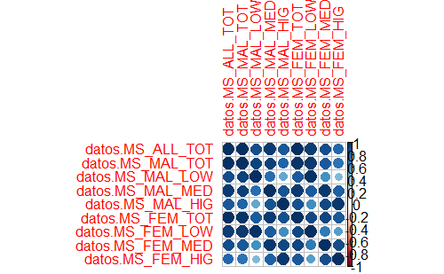

```r
corrplot(res, method = "circle", tl.cex = 0.8)
```

Note que la intensidad y el tamaño del circulo es proporcional al factor de correlación y además la matriz es simétrica

Ahora se usa el **Test de correlación de Pearson** para usar la prueba de hipótesis. Usando el valor *p* se rechaza o no se rechaza la hipótesis nula.

## $H_{0}$: El coeficiente de correlación de la población es cero

## $H_{1}$: El coeficiente de correlación de la población es diferente de cero”

```r
cor.test(datos$MS_MAL_LOW,datos$MS_ALL_TOT,method="pearson")
```

```
    Pearson's product-moment correlation

data:  datos$MS_MAL_LOW and datos$MS_ALL_TOT
t = 38.052, df = 388, p-value < 2.2e-16
alternative hypothesis: true correlation is not equal to 0
95 percent confidence interval:
 0.8650527 0.9073536
sample estimates:
      cor
0.8880684
```

```r
cor.test(datos$MS_MAL_MED,datos$MS_ALL_TOT,method="pearson")
```

```
    Pearson's product-moment correlation

data:  datos$MS_MAL_MED and datos$MS_ALL_TOT
t = 62.374, df = 388, p-value < 2.2e-16
alternative hypothesis: true correlation is not equal to 0
95 percent confidence interval:
 0.9436320 0.9618057
sample estimates:
      cor
0.9535793
```

```r
cor.test(datos$MS_MAL_HIG,datos$MS_ALL_TOT,method="pearson")
```

```
    Pearson's product-moment correlation

data:  datos$MS_MAL_HIG and datos$MS_ALL_TOT
t = 30.599, df = 388, p-value < 2.2e-16
alternative hypothesis: true correlation is not equal to 0
95 percent confidence interval:
 0.8090988 0.8676950
sample estimates:
      cor
0.8408432
```

```r
cor.test(datos$MS_FEM_TOT,datos$MS_ALL_TOT,method="pearson")
```

```
    Pearson's product-moment correlation

data:  datos$MS_FEM_TOT and datos$MS_ALL_TOT
t = 173.86, df = 388, p-value < 2.2e-16
alternative hypothesis: true correlation is not equal to 0
95 percent confidence interval:
 0.9922469 0.9947886
sample estimates:
      cor
0.9936431
```

```r
cor.test(datos$MS_FEM_LOW,datos$MS_ALL_TOT,method="pearson")
```

```
    Pearson's product-moment correlation

data:  datos$MS_FEM_LOW and datos$MS_ALL_TOT
t = 54.373, df = 388, p-value < 2.2e-16
alternative hypothesis: true correlation is not equal to 0
95 percent confidence interval:
 0.9274989 0.9507423
sample estimates:
      cor
0.9402056
```

```r
cor.test(datos$MS_FEM_MED,datos$MS_ALL_TOT,method="pearson")
```

```
    Pearson's product-moment correlation

data:  datos$MS_FEM_MED and datos$MS_ALL_TOT
t = 37.365, df = 388, p-value < 2.2e-16
alternative hypothesis: true correlation is not equal to 0
95 percent confidence interval:
 0.8609324 0.9044588
sample estimates:
      cor
0.8846074
```

```r
cor.test(datos$MS_FEM_HIG,datos$MS_ALL_TOT,method="pearson")
```

```
    Pearson's product-moment correlation

data:  datos$MS_FEM_HIG and datos$MS_ALL_TOT
t = 25.714, df = 388, p-value < 2.2e-16
alternative hypothesis: true correlation is not equal to 0
95 percent confidence interval:
 0.7539823 0.8278867
sample estimates:
      cor
0.7938475
```

2. Ahora se va realizar el análisis de regresión

Para esto vamos hacer un análisis gráfico de las variables de estudio con el objetivo de interpretar los datos y ademas se va a ajustar los parámetros en la regresión lineal con el objetivo de obtener el mejor comportamiento de las variables predictoras (8 cuantitativas y 1 cualitativa “**YEAR**”) y la variable de estudio “**MS_ALL_TOT**”.

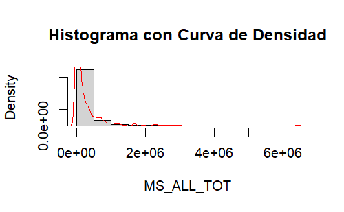

```r
hist(datos$MS_ALL_TOT, xlab = "MS_ALL_TOT", main = "Histograma con Curva de Densidad", freq = FALSE)

lines(density(datos$MS_ALL_TOT), col = "red")
```

*Veamos que la mayoría de los países la variable Total Migration Stock 25+(**MS_ALL_TOT**) representa la cantidad de personas que migran de su país de origen, el cual se encuentra entre el intervalo de 0 a* 500000.

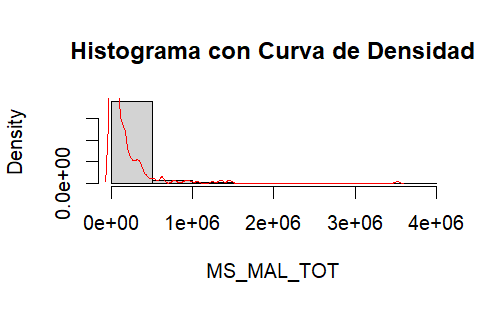

```r
hist(datos$MS_MAL_TOT, xlab = "MS_MAL_TOT", main = "Histograma con Curva de Densidad", freq = FALSE)

lines(density(datos$MS_MAL_TOT), col = "red")
```

*Veamos que la mayoría delos paises la variable Males’ migration stock - All education groups (**MS_MAL_TOT**) representa la cantidad de personas que migran de su pais de origen, el cual se encuentra entre el intervalo de 0 a* 500000.

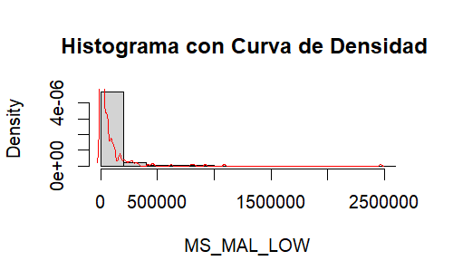

```r
hist(datos$MS_MAL_LOW, xlab = "MS_MAL_LOW", main = "Histograma con Curva de Densidad ", freq = FALSE)

lines(density(datos$MS_MAL_LOW), col = "red")
```

*Veamos que la mayoría de los países la variable Males’ migration stock - Low skilled (**MS_MAL_LOW**) representa la cantidad de personas que migran de su país de origen, el cual se encuentra entre el intervalo de 0 a* 250000.

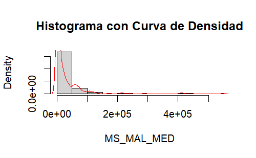

```r
hist(datos$MS_MAL_MED, xlab = "MS_MAL_MED", main = "Histograma con Curva de Densidad", freq = FALSE)

lines(density(datos$MS_MAL_MED), col = "red")
```

*Veamos que la mayoría de los países la variable Males’ migration stock - Medium skilled - All education groups (**MS_MAL_MED**) representa la cantidad de personas que migran de su país de origen, el cual se encuentra entre el intervalo de 0 a* 50000.

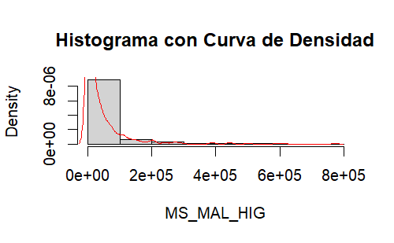

```r
hist(datos$MS_MAL_HIG, xlab = "MS_MAL_HIG", main = "Histograma con Curva de Densidad", freq = FALSE)

lines(density(datos$MS_MAL_HIG), col = "red")
```

*Veamos que la mayoría de los países la variable Males’ migration stock - High skilled (**MS_MAL_HIG**) representa la cantidad de personas que migran de su país de origen, el cual se encuentra entre el intervalo de 0 a* 100000.

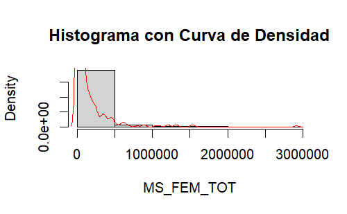

```r
hist(datos$MS_FEM_TOT, xlab = "MS_FEM_TOT", main = "Histograma con Curva de Densidad", freq = FALSE)

lines(density(datos$MS_FEM_TOT), col = "red")
```

*Veamos que la mayoría de los países la variable Females’ migration stock - All education groups (**MS_FEM_TOT**) representa la cantidad de personas que migran de su país de origen, el cual se encuentra entre el intervalo de 0 a* 500000.

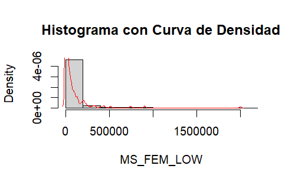

```r
hist(datos$MS_FEM_LOW, xlab = "MS_FEM_LOW", main = "Histograma con Curva de Densidad", freq = FALSE)

lines(density(datos$MS_FEM_LOW), col = "red")
```

*Veamos que la mayoría de los países la variable Females’ migration stock - Low skilled (**MS_FEM_LOW**) representa la cantidad de personas que migran de su país de origen, el cual se encuentra entre el intervalo de 0 a* 250000.

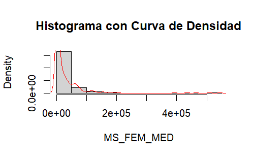

```r
hist(datos$MS_FEM_MED, xlab = "MS_FEM_MED", main = "Histograma con Curva de Densidad", freq = FALSE)

lines(density(datos$MS_FEM_MED), col = "red")
```

*Veamos que la mayoría de los países la variable Females’ migration stock - Medium skilled (**MS_FEM_MED**) representa la cantidad de personas que migran de su país de origen, el cual se encuentra entre el intervalo de 0 a* 50000.

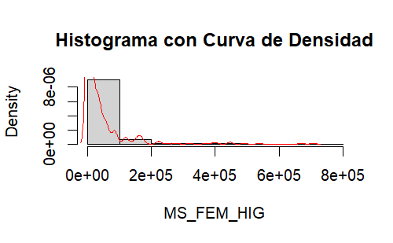

```r
hist(datos$MS_FEM_HIG, xlab = "MS_FEM_HIG", main = "Histograma con Curva de Densidad", freq = FALSE)

lines(density(datos$MS_FEM_HIG), col = "red")
```

*Veamos que la mayoría de los países la variable Females’ migration stock - High skilled (**MS_FEM_HIG**) representa la cantidad de personas que migran de su país de origen, el cual se encuentra entre el intervalo de 0 a* 100000.

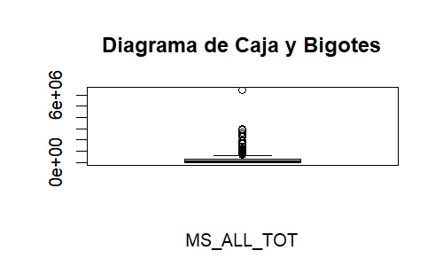

```r
boxplot(datos$MS_ALL_TOT, xlab = "MS_ALL_TOT", main = "Diagrama de Caja y Bigotes")
```

Se observa que con respecto de la línea hacia arriba hay datos atípicos, dicha linea me representa el percentil 95, es decir que de la línea hacia abajo se encuentra el 95% de los datos, y con respecto a la caja es propocional la variabilidad de los datos con respecto al ancho de la caja.

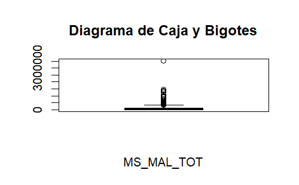

```r
boxplot(datos$MS_MAL_TOT, xlab = "MS_MAL_TOT", main = "Diagrama de Caja y Bigotes")
```

Se observa que con respecto de la línea hacia arriba hay datos atípicos, dicha linea me representa el percentil 95, es decir que de la línea hacia abajo se encuentra el 95% de los datos, y con respecto a la caja es propocional la variabilidad de los datos con respecto al ancho de la caja.

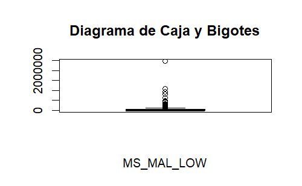

```r
boxplot(datos$MS_MAL_LOW, xlab = "MS_MAL_LOW", main = "Diagrama de Caja y Bigotes")
```

Se observa que con respecto de la línea hacia arriba hay datos atípicos, dicha linea me representa el percentil 95, es decir que de la línea hacia abajo se encuentra el 95% de los datos, y con respecto a la caja es propocional la variabilidad de los datos con respecto al ancho de la caja.

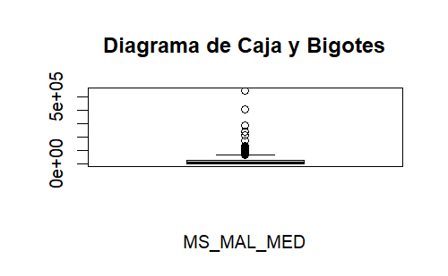

```r
boxplot(datos$MS_MAL_MED, xlab = "MS_MAL_MED", main = "Diagrama de Caja y Bigotes")
```

Se observa que con respecto de la línea hacia arriba hay datos atípicos, dicha linea me representa el percentil 95, es decir que de la línea hacia abajo se encuentra el 95% de los datos, y con respecto a la caja es propocional la variabilidad de los datos con respecto al ancho de la caja.

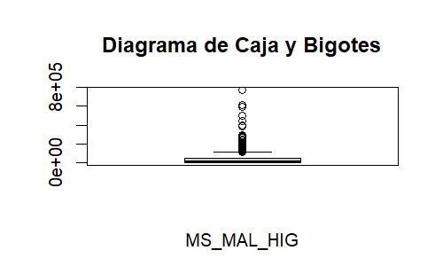

```r
boxplot(datos$MS_MAL_HIG, xlab = "MS_MAL_HIG", main = "Diagrama de Caja y Bigotes")
```

Se observa que con respecto de la línea hacia arriba hay datos atípicos, dicha linea me representa el percentil 95, es decir que de la línea hacia abajo se encuentra el 95% de los datos, y con respecto a la caja es propocional la variabilidad de los datos con respecto al ancho de la caja.

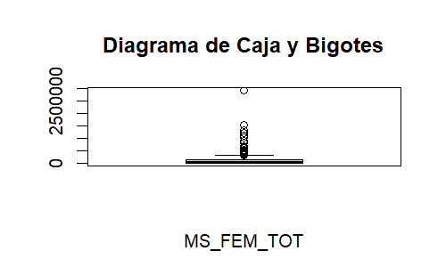

```r
boxplot(datos$MS_FEM_TOT, xlab = "MS_FEM_TOT", main = "Diagrama de Caja y Bigotes")
```

Se observa que con respecto de la línea hacia arriba hay datos atípicos, dicha linea me representa el percentil 95, es decir que de la línea hacia abajo se encuentra el 95% de los datos, y con respecto a la caja es propocional la variabilidad de los datos con respecto al ancho de la caja.

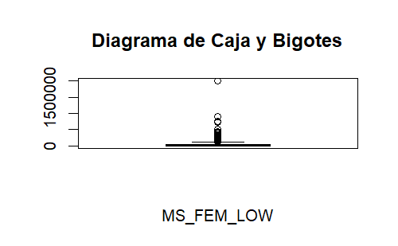

```r
boxplot(datos$MS_FEM_LOW, xlab = "MS_FEM_LOW", main = "Diagrama de Caja y Bigotes")
```

Se observa que con respecto de la línea hacia arriba hay datos atípicos, dicha linea me representa el percentil 95, es decir que de la línea hacia abajo se encuentra el 95% de los datos, y con respecto a la caja es propocional la variabilidad de los datos con respecto al ancho de la caja.

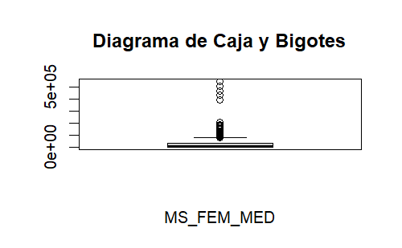

```r
boxplot(datos$MS_FEM_MED, xlab = "MS_FEM_MED", main = "Diagrama de Caja y Bigotes")
```

Se observa que con respecto de la línea hacia arriba hay datos atípicos, dicha linea me representa el percentil 95, es decir que de la línea hacia abajo se encuentra el 95% de los datos, y con respecto a la caja es propocional la variabilidad de los datos con respecto al ancho de la caja.

[figure not shown]

```r
boxplot(datos$MS_FEM_HIG, xlab = "MS_FEM_MED", main = "Diagrama de Caja y Bigotes")
```

Se observa que con respecto de la línea hacia arriba hay datos atípicos, dicha linea me representa el percentil 95, es decir que de la línea hacia abajo se encuentra el 95% de los datos, y con respecto a la caja es proporcional la variabilidad de los datos con respecto al ancho de la caja.

Ahora se va a implementar el modelo de regresión lineal, para esto se va a usar la variable cualitativa *YEAR* para usarla como variable dummy

```r
datos$YEAR <- factor(datos$YEAR)
levels(datos$YEAR) <- c("0","1")
datos
```

[output not shown]

[output cut: 380 more lines]

Ahora se va a ajustar el modelo lineal con respecto a las variables explicativas, vamos a medir el valor *p* de los resultados con respecto a mi variable de estudio en la regresión lineal y solo vamos a tomar 3 variables cuantitativas ya estudiadas en este documento. En particular vamos a usar solo las variables que trata de los hombres.

```r
regresion=lm(datos$MS_ALL_TOT ~  datos$YEAR + datos$MS_MAL_LOW + datos$MS_MAL_MED +  datos$MS_MAL_HIG)
summary(regresion)
```

```
Call:
lm(formula = datos$MS_ALL_TOT ~ datos$YEAR + datos$MS_MAL_LOW +
    datos$MS_MAL_MED + datos$MS_MAL_HIG)

Residuals:
    Min      1Q  Median      3Q     Max
-209656   -6369   -1477    2205  290262

Coefficients:
                   Estimate Std. Error t value Pr(>|t|)
(Intercept)       2.206e+03  2.925e+03   0.754    0.451
datos$YEAR1      -2.831e+03  4.006e+03  -0.707    0.480
datos$MS_MAL_LOW  1.615e+00  2.062e-02  78.342   <2e-16 ***
datos$MS_MAL_MED  2.619e+00  1.128e-01  23.221   <2e-16 ***
datos$MS_MAL_HIG  2.196e+00  5.143e-02  42.709   <2e-16 ***
---
Signif. codes:  0 ‘***’ 0.001 ‘**’ 0.01 ‘*’ 0.05 ‘.’ 0.1 ‘ ’ 1

Residual standard error: 39290 on 385 degrees of freedom
Multiple R-squared:  0.9947,    Adjusted R-squared:  0.9947
F-statistic: 1.81e+04 on 4 and 385 DF,  p-value: < 2.2e-16
```

El modelo para la regresión lineal que se ajusta a las variables predictoras con sus respectivos coeficientes es $Y=2.206\cdot 10^{3}-2.831\cdot10^{3} X_1 +1.615 X_2 + 2.619 X_3 + 2.196 X_4$ donde el *R-squared = 0.99 y con respecto a las variables de estudio.*

*Ahora se va a estudiar los **supuestos** con respecto a los residuos del modelo de regresión lineal ya entrenado, los cuales son:*

- **Independencia**
- **Homocesdasticidad**
- **Normalidad**

## Independencia

Vamos a graficas los errores y seguidamente se hace la prueba de **Dubin-Watson para garantizar** la independencia de los errores.

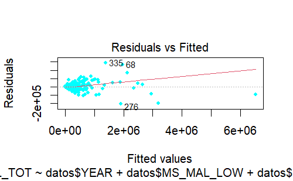

```r
plot(regresion, 1, col = "cyan", pch = 20)
```

Ahora se hace la inferencia con la prueba **Dubin-Watson**

## $H_{0}$: Todo los errores son independientes.

## $H_{1}$: Todos los errores No son independientes.

veamos la inferencia de la prueba **Dubin-Watson**

```r
library(lmtest)
dwtest(regresion, alternative ="two.sided")
```

```
    Durbin-Watson test

data:  regresion
DW = 1.8578, p-value = 0.1446
alternative hypothesis: true autocorrelation is not 0
```

## Homocedasticidad

Veamos que la varianza de los errores sean los mismos usando la prueba de **studentized Breusch-Pagan test**

## $H_{0}$ : Todos los errores tienen la misma varianza.

## $H_{1}$ : Todos los errores No tienen la misma varianza.

```r
bptest(regresion)
```

```
    studentized Breusch-Pagan test

data:  regresion
BP = 185.63, df = 4, p-value < 2.2e-16
```

## Normalidad

Veamos que el error tenga una distribución normal ($N ~ (0,\sigma^2)$) usando la prueba de *Shapiro-Wilk*.

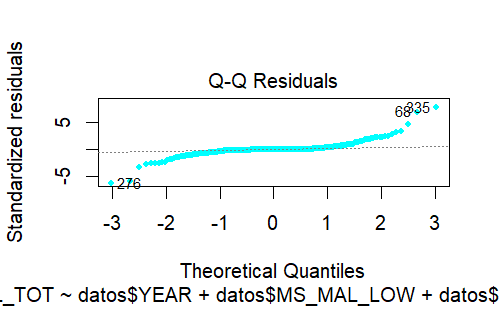

```r
plot(regresion, 2, col = "cyan", pch=20 )
```

## $H_{0}$: Los errores tienen distribución normal.

## $H_{1}$ : Los errores No tienen distribución normal.

```r
shapiro.test(residuals(regresion))
```

```
    Shapiro-Wilk normality test

data:  residuals(regresion)
W = 0.69778, p-value < 2.2e-16
```

## *¿Es necesario hacer algun tipo de transformación de variable?*

```r
res = lm(scale(datos$MS_ALL_TOT) ~ datos$YEAR +  scale(datos$MS_MAL_LOW) + scale( datos$MS_MAL_MED) + scale(datos$MS_MAL_HIG))
summary(res)
```

```
Call:
lm(formula = scale(datos$MS_ALL_TOT) ~ datos$YEAR + scale(datos$MS_MAL_LOW) +
    scale(datos$MS_MAL_MED) + scale(datos$MS_MAL_HIG))

Residuals:
     Min       1Q   Median       3Q      Max
-0.39016 -0.01185 -0.00275  0.00410  0.54017

Coefficients:
                         Estimate Std. Error t value Pr(>|t|)
(Intercept)              0.002634   0.005254   0.501    0.616
datos$YEAR1             -0.005268   0.007455  -0.707    0.480
scale(datos$MS_MAL_LOW)  0.507007   0.006472  78.342   <2e-16 ***
scale(datos$MS_MAL_MED)  0.257366   0.011083  23.221   <2e-16 ***
scale(datos$MS_MAL_HIG)  0.355883   0.008333  42.709   <2e-16 ***
---
Signif. codes:  0 ‘***’ 0.001 ‘**’ 0.01 ‘*’ 0.05 ‘.’ 0.1 ‘ ’ 1

Residual standard error: 0.07311 on 385 degrees of freedom
Multiple R-squared:  0.9947,    Adjusted R-squared:  0.9947
F-statistic: 1.81e+04 on 4 and 385 DF,  p-value: < 2.2e-16
```

**Observación:** Note que $R^{2}$ normalizado es igual que el modelo de regresión lineal sin normalizar, por lo tanto se concluye que **no es necesario** normalizar los datos.

# Análisis de los resultados del modelo

Como el modelo fue:

$Y=2.206\cdot 10^{3}-2.831\cdot10^{3} X_1 +1.615 X_2 + 2.619 X_3 + 2.196 X_4$

Donde:

- $X_1$= Categoría de año, 0 es 1990 y 1 es 2000.
- $X_2$= cantidad de migración de hombres con estudios pocos calificados
- $X_3$= cantidad de migración de hombres con estudios medianamente calificados
- $X_4$= Cantidad de migración de hombres con estudios altamente calificados